# ANCOVA in TDE - Escrita (TDE - Escrita)

Geiser C. Challco geiser@alumni.usp.br

- Descriptive Statistics of Initial Data
- ANCOVA and Pairwise for one factor: **grupo**
  - Without remove non-normal data
  - Computing ANCOVA and PairWise After removing non-normal data (OK)
    - Plots for ancova
    - Checking linearity assumption
    - Checking normality and homogeneity
- ANCOVA and Pairwise for two factors **grupo:Sexo**
  - Without remove non-normal data
  - Computing ANCOVA and PairWise After removing non-normal data (OK)
    - Plots for ancova
    - Checking linearity assumption
    - Checking normality and homogeneity
- ANCOVA and Pairwise for two factors **grupo:Zona**
  - Without remove non-normal data
  - Computing ANCOVA and PairWise After removing non-normal data (OK)
    - Plots for ancova
    - Checking linearity assumption
    - Checking normality and homogeneity
- ANCOVA and Pairwise for two factors **grupo:Cor.Raca**
  - Without remove non-normal data
  - Computing ANCOVA and PairWise After removing non-normal data (OK)
    - Plots for ancova
    - Checking linearity assumption
    - Checking normality and homogeneity
- ANCOVA and Pairwise for two factors **grupo:score.tde.quintile**
  - Without remove non-normal data
  - Computing ANCOVA and PairWise After removing non-normal data (OK)
    - Plots for ancova
    - Checking linearity assumption
    - Checking normality and homogeneity
- Summary of Results
  - Descriptive Statistics
  - ANCOVA Table Comparison
  - PairWise Table Comparison
  - EMMS Table Comparison

**NOTE**:

- Teste ANCOVA para determinar se houve diferenças significativas no TDE - Escrita (medido usando pre- e pos-testes).
- ANCOVA test to determine whether there were significant differences in TDE - Escrita (measured using pre- and post-tests).

# Descriptive Statistics of Initial Data

```r
df <- get.descriptives(dat, c(dv.pre, dv.pos), c("grupo"),
                       include.global = T, symmetry.test = T, normality.test = F)
df <- plyr::rbind.fill(
  df, do.call(plyr::rbind.fill, lapply(lfatores2, FUN = function(f) {
    if (nrow(dat) > 0 && sum(!is.na(unique(dat[[f]]))) > 1)
      get.descriptives(dat, c(dv.pre,dv.pos), c("grupo", f),
                       symmetry.test = T, normality.test = F)
    }))
)
(df <- df[,c(fatores1[fatores1 %in% colnames(df)],"variable",
             colnames(df)[!colnames(df) %in% c(fatores1,"variable")])])
```

```
##           grupo Sexo   Zona Cor.Raca score.tde.quintile      variable   n   mean median min max     sd     se
## 1      Controle <NA>   <NA>     <NA>               <NA> score.tde.pre 134 28.993   26.5   0  63 19.526  1.687
## 2  Experimental <NA>   <NA>     <NA>               <NA> score.tde.pre 159 29.000   29.0   0  65 15.950  1.265
## 3          <NA> <NA>   <NA>     <NA>               <NA> score.tde.pre 293 28.997   29.0   0  65 17.644  1.031
## 4      Controle <NA>   <NA>     <NA>               <NA> score.tde.pos 134 24.231   19.5   0  66 20.155  1.741
## 5  Experimental <NA>   <NA>     <NA>               <NA> score.tde.pos 159 24.094   22.0   0  65 16.759  1.329
## 6          <NA> <NA>   <NA>     <NA>               <NA> score.tde.pos 293 24.157   21.0   0  66 18.358  1.072
## 7      Controle    F   <NA>     <NA>               <NA> score.tde.pre  63 34.587   43.0   2  63 18.464  2.326
## 8      Controle    M   <NA>     <NA>               <NA> score.tde.pre  71 24.028   17.0   0  63 19.216  2.281
## 9  Experimental    F   <NA>     <NA>               <NA> score.tde.pre  83 31.494   34.0   0  59 15.421  1.693
## 10 Experimental    M   <NA>     <NA>               <NA> score.tde.pre  76 26.276   25.5   0  65 16.171  1.855
## 11     Controle    F   <NA>     <NA>               <NA> score.tde.pos  63 30.365   33.0   0  66 19.510  2.458
## 12     Controle    M   <NA>     <NA>               <NA> score.tde.pos  71 18.789   13.0   0  65 19.255  2.285
## 13 Experimental    F   <NA>     <NA>               <NA> score.tde.pos  83 25.494   22.0   0  63 17.274  1.896
## 14 Experimental    M   <NA>     <NA>               <NA> score.tde.pos  76 22.566   22.0   0  65 16.152  1.853
```

[output cut: 98 more lines]

| grupo | Sexo | Zona | Cor.Raca | score.tde.quintile | variable | n | mean | median | min | max | sd | se | ci | iqr | symmetry | skewness | kurtosis |
| --- | --- | --- | --- | --- | --- | --- | --- | --- | --- | --- | --- | --- | --- | --- | --- | --- | --- |
| Controle |  |  |  |  | score.tde.pre | 134 | 28.993 | 26.5 | 0 | 63 | 19.526 | 1.687 | 3.336 | 36.00 | YES | 0.057 | -1.526 |
| Experimental |  |  |  |  | score.tde.pre | 159 | 29.000 | 29.0 | 0 | 65 | 15.950 | 1.265 | 2.498 | 24.50 | YES | -0.043 | -0.909 |
|  |  |  |  |  | score.tde.pre | 293 | 28.997 | 29.0 | 0 | 65 | 17.644 | 1.031 | 2.029 | 32.00 | YES | 0.018 | -1.231 |
| Controle |  |  |  |  | score.tde.pos | 134 | 24.231 | 19.5 | 0 | 66 | 20.155 | 1.741 | 3.444 | 40.00 | YES | 0.381 | -1.295 |
| Experimental |  |  |  |  | score.tde.pos | 159 | 24.094 | 22.0 | 0 | 65 | 16.759 | 1.329 | 2.625 | 26.00 | NO | 0.518 | -0.626 |
|  |  |  |  |  | score.tde.pos | 293 | 24.157 | 21.0 | 0 | 66 | 18.358 | 1.072 | 2.111 | 32.00 | YES | 0.446 | -0.971 |
| Controle | F |  |  |  | score.tde.pre | 63 | 34.587 | 43.0 | 2 | 63 | 18.464 | 2.326 | 4.650 | 32.50 | YES | -0.366 | -1.352 |
| Controle | M |  |  |  | score.tde.pre | 71 | 24.028 | 17.0 | 0 | 63 | 19.216 | 2.281 | 4.548 | 34.50 | YES | 0.457 | -1.290 |
| Experimental | F |  |  |  | score.tde.pre | 83 | 31.494 | 34.0 | 0 | 59 | 15.421 | 1.693 | 3.367 | 26.00 | YES | -0.252 | -0.958 |
| Experimental | M |  |  |  | score.tde.pre | 76 | 26.276 | 25.5 | 0 | 65 | 16.171 | 1.855 | 3.695 | 23.25 | YES | 0.197 | -0.735 |
| Controle | F |  |  |  | score.tde.pos | 63 | 30.365 | 33.0 | 0 | 66 | 19.510 | 2.458 | 4.914 | 34.50 | YES | -0.094 | -1.403 |
| Controle | M |  |  |  | score.tde.pos | 71 | 18.789 | 13.0 | 0 | 65 | 19.255 | 2.285 | 4.558 | 26.00 | NO | 0.885 | -0.553 |
| Experimental | F |  |  |  | score.tde.pos | 83 | 25.494 | 22.0 | 0 | 63 | 17.274 | 1.896 | 3.772 | 28.00 | YES | 0.391 | -0.921 |
| Experimental | M |  |  |  | score.tde.pos | 76 | 22.566 | 22.0 | 0 | 65 | 16.152 | 1.853 | 3.691 | 22.50 | NO | 0.647 | -0.259 |
| Controle |  | Rural |  |  | score.tde.pre | 97 | 29.907 | 27.0 | 0 | 63 | 19.677 | 1.998 | 3.966 | 36.00 | YES | -0.021 | -1.578 |
| Controle |  | Urbana |  |  | score.tde.pre | 21 | 31.143 | 31.0 | 1 | 58 | 18.863 | 4.116 | 8.587 | 34.00 | YES | -0.111 | -1.516 |
| Controle |  |  |  |  | score.tde.pre | 16 | 20.625 | 13.5 | 0 | 62 | 18.478 | 4.620 | 9.846 | 26.75 | NO | 0.773 | -0.709 |
| Experimental |  | Rural |  |  | score.tde.pre | 86 | 25.593 | 25.0 | 0 | 62 | 15.447 | 1.666 | 3.312 | 22.00 | YES | 0.157 | -0.861 |
| Experimental |  | Urbana |  |  | score.tde.pre | 40 | 31.075 | 36.5 | 0 | 65 | 17.016 | 2.691 | 5.442 | 25.75 | YES | -0.255 | -0.966 |
| Experimental |  |  |  |  | score.tde.pre | 33 | 35.364 | 36.0 | 8 | 57 | 13.822 | 2.406 | 4.901 | 22.00 | YES | -0.146 | -1.021 |
| Controle |  | Rural |  |  | score.tde.pos | 97 | 25.979 | 21.0 | 0 | 66 | 20.748 | 2.107 | 4.182 | 40.00 | YES | 0.236 | -1.418 |
| Controle |  | Urbana |  |  | score.tde.pos | 21 | 22.810 | 14.0 | 0 | 58 | 18.870 | 4.118 | 8.589 | 33.00 | YES | 0.482 | -1.280 |
| Controle |  |  |  |  | score.tde.pos | 16 | 15.500 | 12.0 | 0 | 54 | 16.371 | 4.093 | 8.723 | 17.25 | NO | 1.060 | 0.014 |
| Experimental |  | Rural |  |  | score.tde.pos | 86 | 23.488 | 22.0 | 0 | 64 | 15.957 | 1.721 | 3.421 | 21.00 | NO | 0.572 | -0.469 |
| Experimental |  | Urbana |  |  | score.tde.pos | 40 | 20.675 | 16.0 | 0 | 65 | 17.171 | 2.715 | 5.492 | 28.50 | NO | 0.596 | -0.757 |
| Experimental |  |  |  |  | score.tde.pos | 33 | 29.818 | 28.0 | 4 | 63 | 17.368 | 3.023 | 6.158 | 24.00 | YES | 0.312 | -1.011 |
| Controle |  |  | Branca |  | score.tde.pre | 17 | 35.000 | 43.0 | 2 | 62 | 20.616 | 5.000 | 10.600 | 36.00 | YES | -0.313 | -1.570 |
| Controle |  |  | Indígena |  | score.tde.pre | 3 | 34.000 | 46.0 | 4 | 52 | 26.153 | 15.100 | 64.969 | 24.00 | few data | 0.000 | 0.000 |
| Controle |  |  | Parda |  | score.tde.pre | 39 | 28.410 | 27.0 | 0 | 56 | 19.271 | 3.086 | 6.247 | 38.00 | YES | -0.123 | -1.610 |
| Controle |  |  |  |  | score.tde.pre | 75 | 27.733 | 23.0 | 1 | 63 | 19.315 | 2.230 | 4.444 | 35.50 | YES | 0.258 | -1.463 |
| Experimental |  |  | Branca |  | score.tde.pre | 22 | 22.318 | 17.0 | 0 | 49 | 15.410 | 3.285 | 6.832 | 25.25 | YES | 0.307 | -1.327 |
| Experimental |  |  | Indígena |  | score.tde.pre | 11 | 21.818 | 21.0 | 6 | 54 | 16.136 | 4.865 | 10.840 | 25.50 | NO | 0.541 | -1.059 |
| Experimental |  |  | Parda |  | score.tde.pre | 45 | 27.333 | 28.0 | 0 | 62 | 15.744 | 2.347 | 4.730 | 21.00 | YES | -0.037 | -0.770 |
| Experimental |  |  |  |  | score.tde.pre | 81 | 32.716 | 34.0 | 0 | 65 | 15.372 | 1.708 | 3.399 | 22.00 | YES | -0.220 | -0.757 |
| Controle |  |  | Branca |  | score.tde.pos | 17 | 27.647 | 36.0 | 0 | 59 | 22.136 | 5.369 | 11.381 | 41.00 | YES | -0.134 | -1.792 |
| Controle |  |  | Indígena |  | score.tde.pos | 3 | 39.667 | 55.0 | 4 | 60 | 30.989 | 17.892 | 76.982 | 28.00 | few data | 0.000 | 0.000 |
| Controle |  |  | Parda |  | score.tde.pos | 39 | 21.641 | 14.0 | 0 | 60 | 20.220 | 3.238 | 6.555 | 34.00 | NO | 0.537 | -1.269 |
| Controle |  |  |  |  | score.tde.pos | 75 | 24.187 | 20.0 | 0 | 66 | 19.297 | 2.228 | 4.440 | 38.50 | YES | 0.458 | -1.098 |
| Experimental |  |  | Branca |  | score.tde.pos | 22 | 19.682 | 16.5 | 0 | 62 | 14.946 | 3.186 | 6.626 | 13.50 | NO | 0.994 | 0.695 |
| Experimental |  |  | Indígena |  | score.tde.pos | 11 | 25.727 | 23.0 | 1 | 57 | 16.566 | 4.995 | 11.129 | 19.00 | YES | 0.468 | -1.006 |
| Experimental |  |  | Parda |  | score.tde.pos | 45 | 22.222 | 21.0 | 0 | 64 | 16.426 | 2.449 | 4.935 | 24.00 | NO | 0.622 | -0.447 |
| Experimental |  |  |  |  | score.tde.pos | 81 | 26.111 | 24.0 | 0 | 65 | 17.365 | 1.929 | 3.840 | 28.00 | YES | 0.325 | -0.934 |
| Controle |  |  |  | 1st quintile | score.tde.pre | 55 | 8.727 | 8.0 | 0 | 18 | 5.345 | 0.721 | 1.445 | 9.00 | YES | 0.051 | -1.297 |
| Controle |  |  |  | 2nd quintile | score.tde.pre | 17 | 24.235 | 25.0 | 19 | 31 | 3.993 | 0.968 | 2.053 | 7.00 | YES | 0.009 | -1.338 |
| Controle |  |  |  | 3rd quintile | score.tde.pre | 13 | 38.846 | 40.0 | 35 | 42 | 2.794 | 0.775 | 1.689 | 4.00 | YES | -0.235 | -1.708 |
| Controle |  |  |  | 4th quintile | score.tde.pre | 33 | 47.788 | 48.0 | 43 | 51 | 2.559 | 0.445 | 0.907 | 4.00 | YES | -0.433 | -1.024 |
| Controle |  |  |  | 5th quintile | score.tde.pre | 16 | 56.938 | 56.5 | 52 | 63 | 3.820 | 0.955 | 2.036 | 5.75 | YES | 0.280 | -1.409 |
| Experimental |  |  |  | 1st quintile | score.tde.pre | 47 | 9.234 | 9.0 | 0 | 18 | 5.760 | 0.840 | 1.691 | 10.00 | YES | -0.001 | -1.348 |
| Experimental |  |  |  | 2nd quintile | score.tde.pre | 36 | 25.361 | 25.0 | 20 | 30 | 2.929 | 0.488 | 0.991 | 5.25 | YES | 0.117 | -1.257 |
| Experimental |  |  |  | 3rd quintile | score.tde.pre | 43 | 37.116 | 37.0 | 32 | 42 | 3.064 | 0.467 | 0.943 | 5.50 | YES | 0.009 | -1.121 |
| Experimental |  |  |  | 4th quintile | score.tde.pre | 20 | 46.750 | 46.5 | 44 | 50 | 2.074 | 0.464 | 0.971 | 3.25 | YES | 0.116 | -1.572 |
| Experimental |  |  |  | 5th quintile | score.tde.pre | 13 | 56.385 | 56.0 | 52 | 65 | 3.754 | 1.041 | 2.268 | 3.00 | NO | 0.935 | -0.190 |
| Controle |  |  |  | 1st quintile | score.tde.pos | 55 | 7.036 | 4.0 | 0 | 44 | 8.542 | 1.152 | 2.309 | 11.00 | NO | 1.886 | 4.535 |
| Controle |  |  |  | 2nd quintile | score.tde.pos | 17 | 16.529 | 14.0 | 4 | 36 | 10.180 | 2.469 | 5.234 | 13.00 | YES | 0.452 | -1.095 |
| Controle |  |  |  | 3rd quintile | score.tde.pos | 13 | 26.231 | 25.0 | 10 | 51 | 13.230 | 3.669 | 7.995 | 15.00 | NO | 0.630 | -0.852 |
| Controle |  |  |  | 4th quintile | score.tde.pos | 33 | 42.364 | 44.0 | 15 | 60 | 11.261 | 1.960 | 3.993 | 12.00 | NO | -0.753 | 0.325 |
| Controle |  |  |  | 5th quintile | score.tde.pos | 16 | 52.500 | 54.0 | 28 | 66 | 9.359 | 2.340 | 4.987 | 7.75 | NO | -0.940 | 0.728 |
| Experimental |  |  |  | 1st quintile | score.tde.pos | 47 | 9.681 | 7.0 | 0 | 29 | 7.667 | 1.118 | 2.251 | 11.00 | NO | 0.614 | -0.653 |
| Experimental |  |  |  | 2nd quintile | score.tde.pos | 36 | 19.500 | 19.5 | 0 | 46 | 11.732 | 1.955 | 3.969 | 13.50 | YES | 0.352 | -0.501 |
| Experimental |  |  |  | 3rd quintile | score.tde.pos | 43 | 28.651 | 29.0 | 8 | 50 | 12.002 | 1.830 | 3.694 | 20.50 | YES | -0.052 | -1.091 |
| Experimental |  |  |  | 4th quintile | score.tde.pos | 20 | 37.700 | 40.5 | 10 | 62 | 14.124 | 3.158 | 6.610 | 18.75 | YES | -0.207 | -0.911 |
| Experimental |  |  |  | 5th quintile | score.tde.pos | 13 | 52.923 | 52.0 | 40 | 65 | 9.535 | 2.644 | 5.762 | 18.00 | YES | -0.067 | -1.780 |

# ANCOVA and Pairwise for one factor: **grupo**

## Without remove non-normal data

```r
pdat = remove_group_data(dat[!is.na(dat[["grupo"]]),], "score.tde.pos", "grupo")

pdat.long <- rbind(pdat[,c("id","grupo")], pdat[,c("id","grupo")])
pdat.long[["time"]] <- c(rep("pre", nrow(pdat)), rep("pos", nrow(pdat)))
pdat.long[["time"]] <- factor(pdat.long[["time"]], c("pre","pos"))
pdat.long[["score.tde"]] <- c(pdat[["score.tde.pre"]], pdat[["score.tde.pos"]])

aov = anova_test(pdat, score.tde.pos ~ score.tde.pre + grupo)
laov[["grupo"]] <- get_anova_table(aov)
```

```r
pwc <- emmeans_test(pdat, score.tde.pos ~ grupo, covariate = score.tde.pre,
                    p.adjust.method = "bonferroni")
```

```r
pwc.long <- emmeans_test(dplyr::group_by_at(pdat.long, "grupo"),
                          score.tde ~ time,
                          p.adjust.method = "bonferroni")
lpwc[["grupo"]] <- plyr::rbind.fill(pwc, pwc.long)
```

```r
ds <- get.descriptives(pdat, "score.tde.pos", "grupo", covar = "score.tde.pre")
ds <- merge(ds[ds$variable != "score.tde.pre",],
            ds[ds$variable == "score.tde.pre", !colnames(ds) %in% c("variable")],
            by = "grupo", all.x = T, suffixes = c("", ".score.tde.pre"))
ds <- merge(get_emmeans(pwc), ds, by = "grupo", suffixes = c(".emms", ""))
ds <- ds[,c("grupo","n","mean.score.tde.pre","se.score.tde.pre","mean","se","emmean","se.emms")]

colnames(ds) <- c("grupo", "N", paste0(c("M","SE")," (pre)"),
                  paste0(c("M","SE"), " (unadj)"), paste0(c("M", "SE"), " (adj)"))

lemms[["grupo"]] <- ds
```

## Computing ANCOVA and PairWise After removing non-normal data (OK)

```r
wdat = pdat

res = residuals(lm(score.tde.pos ~ score.tde.pre + grupo, data = wdat))
non.normal = getNonNormal(res, wdat$id, plimit = 0.05)

wdat = wdat[!wdat$id %in% non.normal,]

wdat.long <- rbind(wdat[,c("id","grupo")], wdat[,c("id","grupo")])
wdat.long[["time"]] <- c(rep("pre", nrow(wdat)), rep("pos", nrow(wdat)))
wdat.long[["time"]] <- factor(wdat.long[["time"]], c("pre","pos"))
wdat.long[["score.tde"]] <- c(wdat[["score.tde.pre"]], wdat[["score.tde.pos"]])

ldat[["grupo"]] = wdat

(non.normal)
```

```r
aov = anova_test(wdat, score.tde.pos ~ score.tde.pre + grupo)
laov[["grupo"]] <- merge(get_anova_table(aov), laov[["grupo"]], by="Effect", suffixes = c("","'"))

(df = get_anova_table(aov))
```

```
## ANOVA Table (type II tests)
##
##          Effect DFn DFd       F        p p<.05      ges
## 1 score.tde.pre   1 290 635.737 4.55e-75     * 6.87e-01
## 2         grupo   1 290   0.014 9.06e-01       4.85e-05
```

| Effect | DFn | DFd | F | p | p<.05 | ges |
| --- | --- | --- | --- | --- | --- | --- |
| score.tde.pre | 1 | 290 | 635.737 | 0.000 | * | 0.687 |
| grupo | 1 | 290 | 0.014 | 0.906 |  | 0.000 |

[output not shown]

```r
pwc.long <- emmeans_test(dplyr::group_by_at(wdat.long, "grupo"),
                         score.tde ~ time,
                         p.adjust.method = "bonferroni")
lpwc[["grupo"]] <- merge(plyr::rbind.fill(pwc, pwc.long), lpwc[["grupo"]], by=c("grupo","term",".y.","group1","group2"), suffixes = c("","'"))
```

| grupo | term | .y. | group1 | group2 | df | statistic | p | p.adj | p.adj.signif |
| --- | --- | --- | --- | --- | --- | --- | --- | --- | --- |
| Controle | time | score.tde | pre | pos | 582 | 2.161 | 0.031 | 0.031 | * |
| Experimental | time | score.tde | pre | pos | 582 | 2.425 | 0.016 | 0.016 | * |

```r
ds <- get.descriptives(wdat, "score.tde.pos", "grupo", covar = "score.tde.pre")
ds <- merge(ds[ds$variable != "score.tde.pre",],
            ds[ds$variable == "score.tde.pre", !colnames(ds) %in% c("variable")],
            by = "grupo", all.x = T, suffixes = c("", ".score.tde.pre"))
ds <- merge(get_emmeans(pwc), ds, by = "grupo", suffixes = c(".emms", ""))
ds <- ds[,c("grupo","n","mean.score.tde.pre","se.score.tde.pre","mean","se","emmean","se.emms")]

colnames(ds) <- c("grupo", "N", paste0(c("M","SE")," (pre)"),
                  paste0(c("M","SE"), " (unadj)"), paste0(c("M", "SE"), " (adj)"))

lemms[["grupo"]] <- merge(ds, lemms[["grupo"]], by=c("grupo"), suffixes = c("","'"))
```

| grupo | N | M (pre) | SE (pre) | M (unadj) | SE (unadj) | M (adj) | SE (adj) |
| --- | --- | --- | --- | --- | --- | --- | --- |
| Controle | 134 | 28.993 | 1.687 | 24.231 | 1.741 | 24.235 | 0.891 |
| Experimental | 159 | 29.000 | 1.265 | 24.094 | 1.329 | 24.091 | 0.818 |

### Plots for ancova

```r
plots <- oneWayAncovaPlots(
  wdat, "score.tde.pos", "grupo", aov, list("grupo"=pwc), addParam = c("mean_se"),
  font.label.size=10, step.increase=0.05, p.label="p.adj",
  subtitle = which(aov$Effect == "grupo"))
```

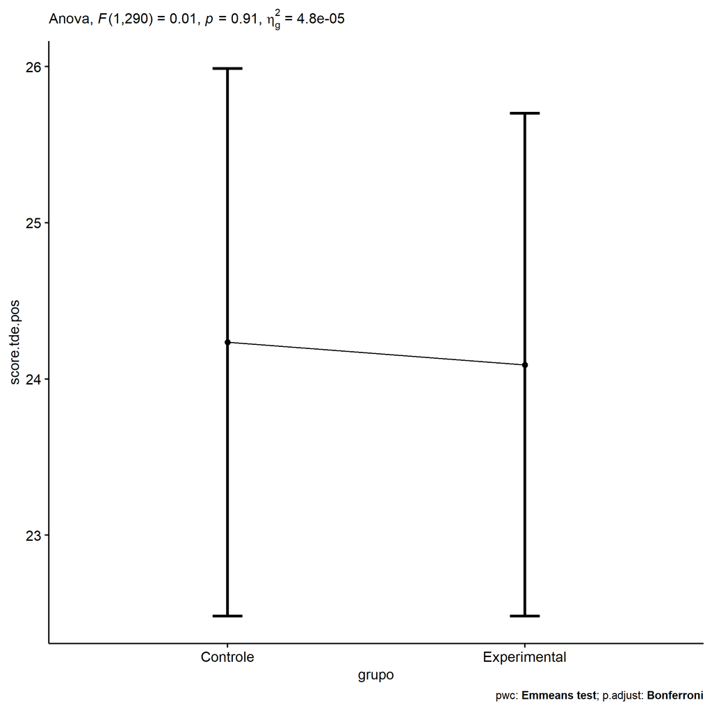

```r
if (!is.null(nrow(plots[["grupo"]]$data)))
  plots[["grupo"]] + ggplot2::scale_color_manual(values = color[["grupo"]])
```

```r
plots <- oneWayAncovaBoxPlots(
  wdat, "score.tde.pos", "grupo", aov, pwc, covar = "score.tde.pre",
  theme = "classic", color = color[["grupo"]],
  subtitle = which(aov$Effect == "grupo"))
```

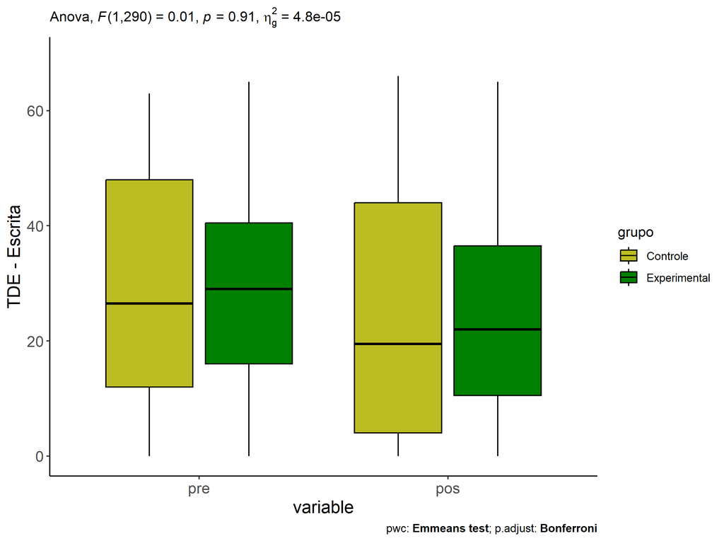

```r
if (length(unique(wdat[["grupo"]])) > 1)
  plots[["grupo"]] + ggplot2::ylab("TDE - Escrita") + ggplot2::scale_x_discrete(labels=c('pre', 'pos'))
```

```r
if (length(unique(wdat.long[["grupo"]])) > 1)
  plots <- oneWayAncovaBoxPlots(
    wdat.long, "score.tde", "grupo", aov, pwc.long, pre.post = "time",
    theme = "classic", color = color$prepost)
```

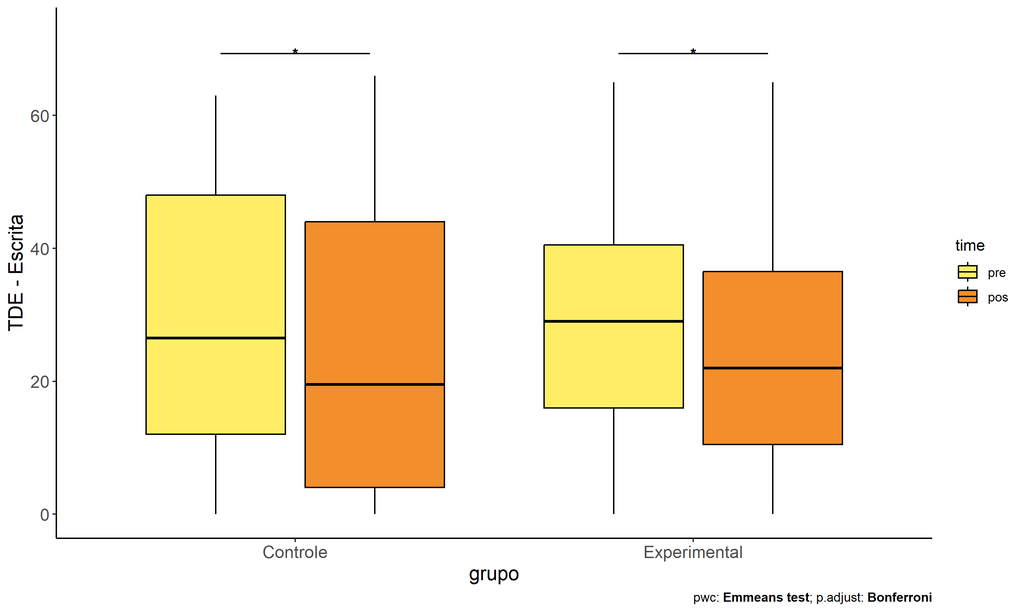

```r
if (length(unique(wdat.long[["grupo"]])) > 1)
  plots[["grupo"]] + ggplot2::ylab("TDE - Escrita")
```

### Checking linearity assumption

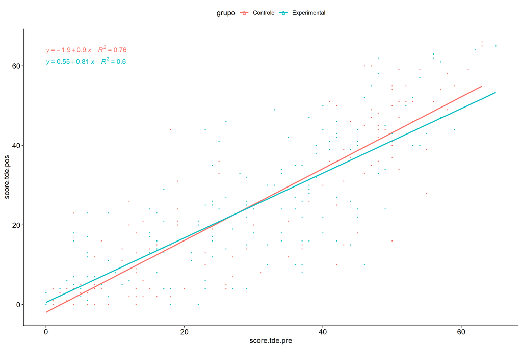

```r
ggscatter(wdat, x = "score.tde.pre", y = "score.tde.pos", size = 0.5,
          color = "grupo", add = "reg.line")+
  stat_regline_equation(
    aes(label =  paste(..eq.label.., ..rr.label.., sep = "~~~~"), color = grupo)
  )
```

### Checking normality and homogeneity

```r
res <- augment(lm(score.tde.pos ~ score.tde.pre + grupo, data = wdat))
```

```r
shapiro_test(res$.resid)
```

```
## # A tibble: 1 × 3
##   variable   statistic p.value
##   <chr>          <dbl>   <dbl>
## 1 res$.resid     0.994   0.280
```

```r
levene_test(res, .resid ~ grupo)
```

```
## # A tibble: 1 × 4
##     df1   df2 statistic     p
##   <int> <int>     <dbl> <dbl>
## 1     1   291      1.15 0.285
```

# ANCOVA and Pairwise for two factors **grupo:Sexo**

## Without remove non-normal data

```r
pdat = remove_group_data(dat[!is.na(dat[["grupo"]]) & !is.na(dat[["Sexo"]]),], "score.tde.pos", c("grupo","Sexo"))

pdat.long <- rbind(pdat[,c("id","grupo","Sexo")], pdat[,c("id","grupo","Sexo")])
pdat.long[["time"]] <- c(rep("pre", nrow(pdat)), rep("pos", nrow(pdat)))
pdat.long[["time"]] <- factor(pdat.long[["time"]], c("pre","pos"))
pdat.long[["score.tde"]] <- c(pdat[["score.tde.pre"]], pdat[["score.tde.pos"]])

aov = anova_test(pdat, score.tde.pos ~ score.tde.pre + grupo*Sexo)
laov[["grupo:Sexo"]] <- get_anova_table(aov)
```

```r
pwcs <- list()
pwcs[["Sexo"]] <- emmeans_test(
  group_by(pdat, grupo), score.tde.pos ~ Sexo,
  covariate = score.tde.pre, p.adjust.method = "bonferroni")
pwcs[["grupo"]] <- emmeans_test(
  group_by(pdat, Sexo), score.tde.pos ~ grupo,
  covariate = score.tde.pre, p.adjust.method = "bonferroni")

pwc <- plyr::rbind.fill(pwcs[["grupo"]], pwcs[["Sexo"]])
pwc <- pwc[,c("grupo","Sexo", colnames(pwc)[!colnames(pwc) %in% c("grupo","Sexo")])]
```

```r
pwc.long <- emmeans_test(dplyr::group_by_at(pdat.long, c("grupo","Sexo")),
                         score.tde ~ time,
                         p.adjust.method = "bonferroni")
lpwc[["grupo:Sexo"]] <- plyr::rbind.fill(pwc, pwc.long)
```

```r
ds <- get.descriptives(pdat, "score.tde.pos", c("grupo","Sexo"), covar = "score.tde.pre")
ds <- merge(ds[ds$variable != "score.tde.pre",],
            ds[ds$variable == "score.tde.pre", !colnames(ds) %in% c("variable")],
            by = c("grupo","Sexo"), all.x = T, suffixes = c("", ".score.tde.pre"))
ds <- merge(get_emmeans(pwcs[["grupo"]]), ds, by = c("grupo","Sexo"), suffixes = c(".emms", ""))
ds <- ds[,c("grupo","Sexo","n","mean.score.tde.pre","se.score.tde.pre","mean","se","emmean","se.emms")]

colnames(ds) <- c("grupo","Sexo", "N", paste0(c("M","SE")," (pre)"),
                  paste0(c("M","SE"), " (unadj)"), paste0(c("M", "SE"), " (adj)"))

lemms[["grupo:Sexo"]] <- ds
```

## Computing ANCOVA and PairWise After removing non-normal data (OK)

```r
wdat = pdat

res = residuals(lm(score.tde.pos ~ score.tde.pre + grupo*Sexo, data = wdat))
non.normal = getNonNormal(res, wdat$id, plimit = 0.05)

wdat = wdat[!wdat$id %in% non.normal,]

wdat.long <- rbind(wdat[,c("id","grupo","Sexo")], wdat[,c("id","grupo","Sexo")])
wdat.long[["time"]] <- c(rep("pre", nrow(wdat)), rep("pos", nrow(wdat)))
wdat.long[["time"]] <- factor(wdat.long[["time"]], c("pre","pos"))
wdat.long[["score.tde"]] <- c(wdat[["score.tde.pre"]], wdat[["score.tde.pos"]])


ldat[["grupo:Sexo"]] = wdat

(non.normal)
```

```r
aov = anova_test(wdat, score.tde.pos ~ score.tde.pre + grupo*Sexo)
laov[["grupo:Sexo"]] <- merge(get_anova_table(aov), laov[["grupo:Sexo"]], by="Effect", suffixes = c("","'"))

(df = get_anova_table(aov))
```

```
## ANOVA Table (type II tests)
##
##          Effect DFn DFd       F        p p<.05      ges
## 1 score.tde.pre   1 288 595.129 4.81e-72     * 6.74e-01
## 2         grupo   1 288   0.017 8.96e-01       5.97e-05
## 3          Sexo   1 288   0.055 8.14e-01       1.92e-04
## 4    grupo:Sexo   1 288   2.826 9.40e-02       1.00e-02
```

| Effect | DFn | DFd | F | p | p<.05 | ges |
| --- | --- | --- | --- | --- | --- | --- |
| score.tde.pre | 1 | 288 | 595.129 | 0.000 | * | 0.674 |
| grupo | 1 | 288 | 0.017 | 0.896 |  | 0.000 |
| Sexo | 1 | 288 | 0.055 | 0.814 |  | 0.000 |
| grupo:Sexo | 1 | 288 | 2.826 | 0.094 |  | 0.010 |

```r
pwcs <- list()
pwcs[["Sexo"]] <- emmeans_test(
  group_by(wdat, grupo), score.tde.pos ~ Sexo,
  covariate = score.tde.pre, p.adjust.method = "bonferroni")
pwcs[["grupo"]] <- emmeans_test(
  group_by(wdat, Sexo), score.tde.pos ~ grupo,
  covariate = score.tde.pre, p.adjust.method = "bonferroni")

pwc <- plyr::rbind.fill(pwcs[["grupo"]], pwcs[["Sexo"]])
pwc <- pwc[,c("grupo","Sexo", colnames(pwc)[!colnames(pwc) %in% c("grupo","Sexo")])]
```

| grupo | Sexo | term | .y. | group1 | group2 | df | statistic | p | p.adj | p.adj.signif |
| --- | --- | --- | --- | --- | --- | --- | --- | --- | --- | --- |
|  | F | score.tde.pre*grupo | score.tde.pos | Controle | Experimental | 288 | 1.290 | 0.198 | 0.198 | ns |
|  | M | score.tde.pre*grupo | score.tde.pos | Controle | Experimental | 288 | -1.089 | 0.277 | 0.277 | ns |
| Controle |  | score.tde.pre*Sexo | score.tde.pos | F | M | 288 | 1.395 | 0.164 | 0.164 | ns |
| Experimental |  | score.tde.pre*Sexo | score.tde.pos | F | M | 288 | -0.935 | 0.351 | 0.351 | ns |

```r
pwc.long <- emmeans_test(dplyr::group_by_at(wdat.long, c("grupo","Sexo")),
                         score.tde ~ time,
                         p.adjust.method = "bonferroni")
lpwc[["grupo:Sexo"]] <- merge(plyr::rbind.fill(pwc, pwc.long), lpwc[["grupo:Sexo"]], by=c("grupo","Sexo","term",".y.","group1","group2"), suffixes = c("","'"))
```

| grupo | Sexo | term | .y. | group1 | group2 | df | statistic | p | p.adj | p.adj.signif |
| --- | --- | --- | --- | --- | --- | --- | --- | --- | --- | --- |
| Controle | F | time | score.tde | pre | pos | 578 | 1.344 | 0.179 | 0.179 | ns |
| Controle | M | time | score.tde | pre | pos | 578 | 1.771 | 0.077 | 0.077 | ns |
| Experimental | F | time | score.tde | pre | pos | 578 | 2.192 | 0.029 | 0.029 | * |
| Experimental | M | time | score.tde | pre | pos | 578 | 1.297 | 0.195 | 0.195 | ns |

```r
ds <- get.descriptives(wdat, "score.tde.pos", c("grupo","Sexo"), covar = "score.tde.pre")
ds <- merge(ds[ds$variable != "score.tde.pre",],
            ds[ds$variable == "score.tde.pre", !colnames(ds) %in% c("variable")],
            by = c("grupo","Sexo"), all.x = T, suffixes = c("", ".score.tde.pre"))
ds <- merge(get_emmeans(pwcs[["grupo"]]), ds, by = c("grupo","Sexo"), suffixes = c(".emms", ""))
ds <- ds[,c("grupo","Sexo","n","mean.score.tde.pre","se.score.tde.pre","mean","se","emmean","se.emms")]

colnames(ds) <- c("grupo","Sexo", "N", paste0(c("M","SE")," (pre)"),
                  paste0(c("M","SE"), " (unadj)"), paste0(c("M", "SE"), " (adj)"))

lemms[["grupo:Sexo"]] <- merge(ds, lemms[["grupo:Sexo"]], by=c("grupo","Sexo"), suffixes = c("","'"))
```

| grupo | Sexo | N | M (pre) | SE (pre) | M (unadj) | SE (unadj) | M (adj) | SE (adj) |
| --- | --- | --- | --- | --- | --- | --- | --- | --- |
| Controle | F | 63 | 34.587 | 2.326 | 30.365 | 2.458 | 25.580 | 1.312 |
| Controle | M | 71 | 24.028 | 2.281 | 18.789 | 2.285 | 23.041 | 1.234 |
| Experimental | F | 83 | 31.494 | 1.693 | 25.494 | 1.896 | 23.357 | 1.133 |
| Experimental | M | 76 | 26.276 | 1.855 | 22.566 | 1.853 | 24.894 | 1.185 |

### Plots for ancova

```r
plots <- twoWayAncovaPlots(
  wdat, "score.tde.pos", c("grupo","Sexo"), aov, pwcs, addParam = c("mean_se"),
  font.label.size=10, step.increase=0.05, p.label="p.adj",
  subtitle = which(aov$Effect == "grupo:Sexo"))
```

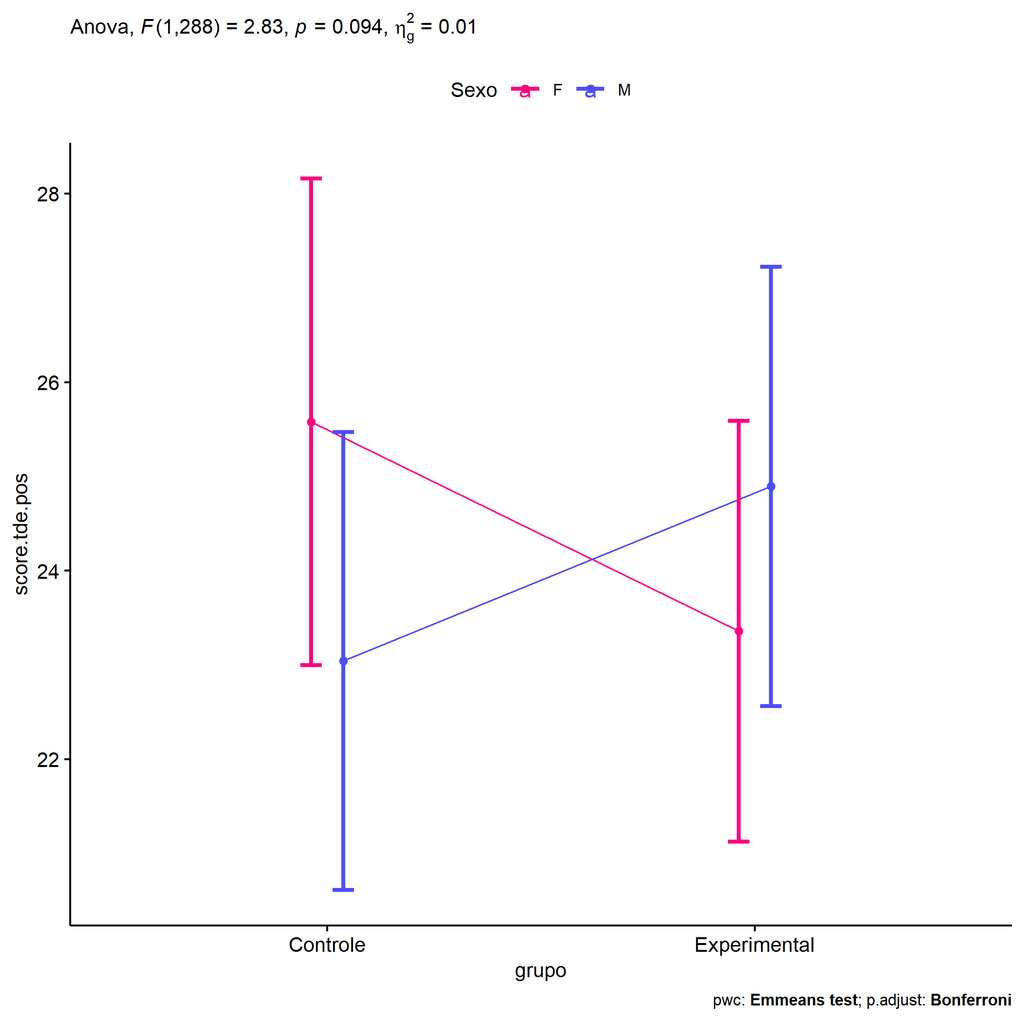

```r
if (!is.null(plots[["grupo"]]))
  plots[["grupo"]] + ggplot2::scale_color_manual(values = color[["Sexo"]])
```

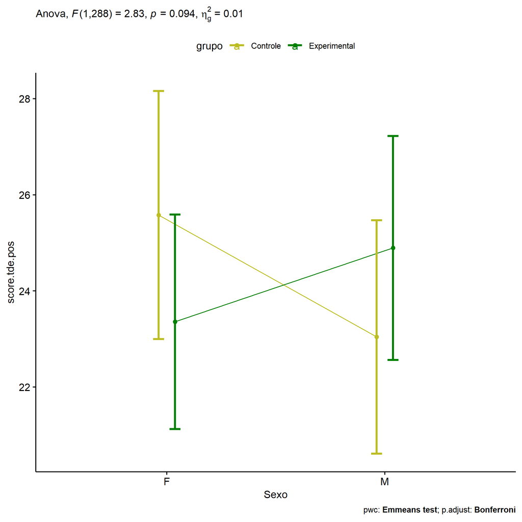

```r
if (!is.null(plots[["Sexo"]]))
  plots[["Sexo"]] + ggplot2::scale_color_manual(values = color[["grupo"]])
```

```r
plots <- twoWayAncovaBoxPlots(
  wdat, "score.tde.pos", c("grupo","Sexo"), aov, pwcs, covar = "score.tde.pre",
  theme = "classic", color = color[["grupo:Sexo"]],
  subtitle = which(aov$Effect == "grupo:Sexo"))
```

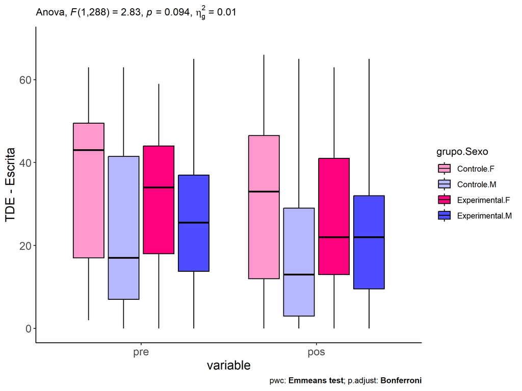

```r
plots[["grupo:Sexo"]] + ggplot2::ylab("TDE - Escrita") + ggplot2::scale_x_discrete(labels=c('pre', 'pos'))
```

```r
plots <- twoWayAncovaBoxPlots(
  wdat.long, "score.tde", c("grupo","Sexo"), aov, pwc.long, pre.post = "time",
  theme = "classic", color = color$prepost)
```

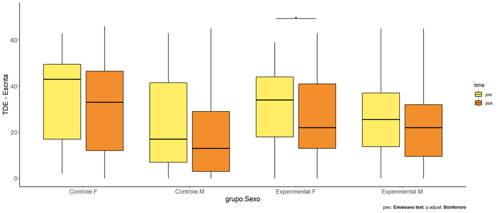

```r
plots[["grupo:Sexo"]] + ggplot2::ylab("TDE - Escrita")
```

### Checking linearity assumption

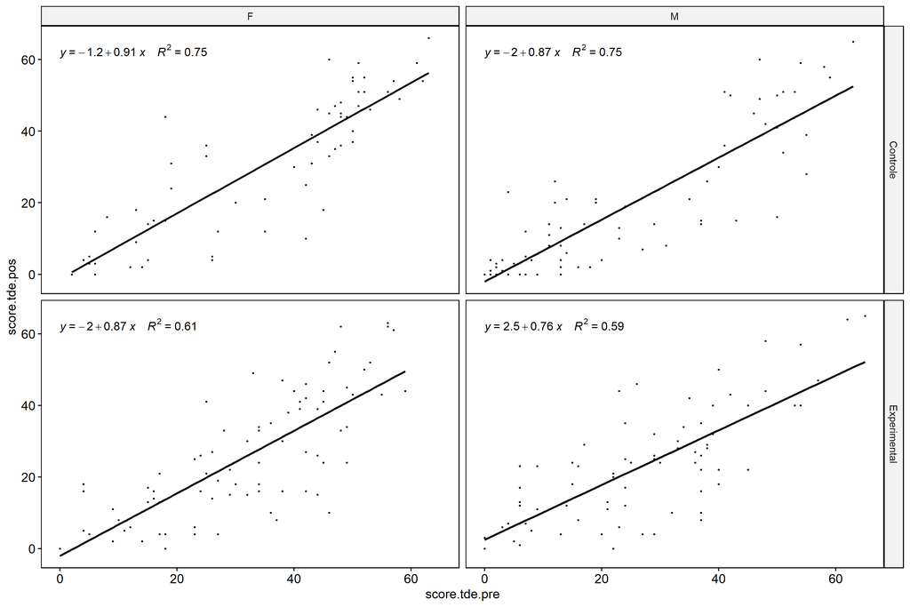

```r
ggscatter(wdat, x = "score.tde.pre", y = "score.tde.pos", size = 0.5,
          facet.by = c("grupo","Sexo"), add = "reg.line")+
  stat_regline_equation(
    aes(label =  paste(..eq.label.., ..rr.label.., sep = "~~~~"))
  )
```

### Checking normality and homogeneity

```r
res <- augment(lm(score.tde.pos ~ score.tde.pre + grupo*Sexo, data = wdat))
```

```r
shapiro_test(res$.resid)
```

```
## # A tibble: 1 × 3
##   variable   statistic p.value
##   <chr>          <dbl>   <dbl>
## 1 res$.resid     0.994   0.252
```

```r
levene_test(res, .resid ~ grupo*Sexo)
```

```
## # A tibble: 1 × 4
##     df1   df2 statistic     p
##   <int> <int>     <dbl> <dbl>
## 1     3   289     0.532 0.661
```

# ANCOVA and Pairwise for two factors **grupo:Zona**

## Without remove non-normal data

```r
pdat = remove_group_data(dat[!is.na(dat[["grupo"]]) & !is.na(dat[["Zona"]]),], "score.tde.pos", c("grupo","Zona"))

pdat.long <- rbind(pdat[,c("id","grupo","Zona")], pdat[,c("id","grupo","Zona")])
pdat.long[["time"]] <- c(rep("pre", nrow(pdat)), rep("pos", nrow(pdat)))
pdat.long[["time"]] <- factor(pdat.long[["time"]], c("pre","pos"))
pdat.long[["score.tde"]] <- c(pdat[["score.tde.pre"]], pdat[["score.tde.pos"]])

aov = anova_test(pdat, score.tde.pos ~ score.tde.pre + grupo*Zona)
laov[["grupo:Zona"]] <- get_anova_table(aov)
```

```r
pwcs <- list()
pwcs[["Zona"]] <- emmeans_test(
  group_by(pdat, grupo), score.tde.pos ~ Zona,
  covariate = score.tde.pre, p.adjust.method = "bonferroni")
pwcs[["grupo"]] <- emmeans_test(
  group_by(pdat, Zona), score.tde.pos ~ grupo,
  covariate = score.tde.pre, p.adjust.method = "bonferroni")

pwc <- plyr::rbind.fill(pwcs[["grupo"]], pwcs[["Zona"]])
pwc <- pwc[,c("grupo","Zona", colnames(pwc)[!colnames(pwc) %in% c("grupo","Zona")])]
```

```r
pwc.long <- emmeans_test(dplyr::group_by_at(pdat.long, c("grupo","Zona")),
                         score.tde ~ time,
                         p.adjust.method = "bonferroni")
lpwc[["grupo:Zona"]] <- plyr::rbind.fill(pwc, pwc.long)
```

```r
ds <- get.descriptives(pdat, "score.tde.pos", c("grupo","Zona"), covar = "score.tde.pre")
ds <- merge(ds[ds$variable != "score.tde.pre",],
            ds[ds$variable == "score.tde.pre", !colnames(ds) %in% c("variable")],
            by = c("grupo","Zona"), all.x = T, suffixes = c("", ".score.tde.pre"))
ds <- merge(get_emmeans(pwcs[["grupo"]]), ds, by = c("grupo","Zona"), suffixes = c(".emms", ""))
ds <- ds[,c("grupo","Zona","n","mean.score.tde.pre","se.score.tde.pre","mean","se","emmean","se.emms")]

colnames(ds) <- c("grupo","Zona", "N", paste0(c("M","SE")," (pre)"),
                  paste0(c("M","SE"), " (unadj)"), paste0(c("M", "SE"), " (adj)"))

lemms[["grupo:Zona"]] <- ds
```

## Computing ANCOVA and PairWise After removing non-normal data (OK)

```r
wdat = pdat

res = residuals(lm(score.tde.pos ~ score.tde.pre + grupo*Zona, data = wdat))
non.normal = getNonNormal(res, wdat$id, plimit = 0.05)

wdat = wdat[!wdat$id %in% non.normal,]

wdat.long <- rbind(wdat[,c("id","grupo","Zona")], wdat[,c("id","grupo","Zona")])
wdat.long[["time"]] <- c(rep("pre", nrow(wdat)), rep("pos", nrow(wdat)))
wdat.long[["time"]] <- factor(wdat.long[["time"]], c("pre","pos"))
wdat.long[["score.tde"]] <- c(wdat[["score.tde.pre"]], wdat[["score.tde.pos"]])


ldat[["grupo:Zona"]] = wdat

(non.normal)
```

```r
aov = anova_test(wdat, score.tde.pos ~ score.tde.pre + grupo*Zona)
laov[["grupo:Zona"]] <- merge(get_anova_table(aov), laov[["grupo:Zona"]], by="Effect", suffixes = c("","'"))

(df = get_anova_table(aov))
```

```
## ANOVA Table (type II tests)
##
##          Effect DFn DFd       F        p p<.05      ges
## 1 score.tde.pre   1 239 524.136 3.47e-62     * 0.687000
## 2         grupo   1 239   0.110 7.41e-01       0.000459
## 3          Zona   1 239  16.101 8.04e-05     * 0.063000
## 4    grupo:Zona   1 239   1.070 3.02e-01       0.004000
```

| Effect | DFn | DFd | F | p | p<.05 | ges |
| --- | --- | --- | --- | --- | --- | --- |
| score.tde.pre | 1 | 239 | 524.136 | 0.000 | * | 0.687 |
| grupo | 1 | 239 | 0.110 | 0.741 |  | 0.000 |
| Zona | 1 | 239 | 16.101 | 0.000 | * | 0.063 |
| grupo:Zona | 1 | 239 | 1.070 | 0.302 |  | 0.004 |

```r
pwcs <- list()
pwcs[["Zona"]] <- emmeans_test(
  group_by(wdat, grupo), score.tde.pos ~ Zona,
  covariate = score.tde.pre, p.adjust.method = "bonferroni")
pwcs[["grupo"]] <- emmeans_test(
  group_by(wdat, Zona), score.tde.pos ~ grupo,
  covariate = score.tde.pre, p.adjust.method = "bonferroni")

pwc <- plyr::rbind.fill(pwcs[["grupo"]], pwcs[["Zona"]])
pwc <- pwc[,c("grupo","Zona", colnames(pwc)[!colnames(pwc) %in% c("grupo","Zona")])]
```

| grupo | Zona | term | .y. | group1 | group2 | df | statistic | p | p.adj | p.adj.signif |
| --- | --- | --- | --- | --- | --- | --- | --- | --- | --- | --- |
|  | Rural | score.tde.pre*grupo | score.tde.pos | Controle | Experimental | 239 | -0.790 | 0.430 | 0.430 | ns |
|  | Urbana | score.tde.pre*grupo | score.tde.pos | Controle | Experimental | 239 | 0.745 | 0.457 | 0.457 | ns |
| Controle |  | score.tde.pre*Zona | score.tde.pos | Rural | Urbana | 239 | 1.700 | 0.090 | 0.090 | ns |
| Experimental |  | score.tde.pre*Zona | score.tde.pos | Rural | Urbana | 239 | 3.782 | 0.000 | 0.000 | *** |

```r
pwc.long <- emmeans_test(dplyr::group_by_at(wdat.long, c("grupo","Zona")),
                         score.tde ~ time,
                         p.adjust.method = "bonferroni")
lpwc[["grupo:Zona"]] <- merge(plyr::rbind.fill(pwc, pwc.long), lpwc[["grupo:Zona"]], by=c("grupo","Zona","term",".y.","group1","group2"), suffixes = c("","'"))
```

| grupo | Zona | term | .y. | group1 | group2 | df | statistic | p | p.adj | p.adj.signif |
| --- | --- | --- | --- | --- | --- | --- | --- | --- | --- | --- |
| Controle | Rural | time | score.tde | pre | pos | 480 | 1.510 | 0.132 | 0.132 | ns |
| Controle | Urbana | time | score.tde | pre | pos | 480 | 1.491 | 0.137 | 0.137 | ns |
| Experimental | Rural | time | score.tde | pre | pos | 480 | 0.762 | 0.446 | 0.446 | ns |
| Experimental | Urbana | time | score.tde | pre | pos | 480 | 2.568 | 0.011 | 0.011 | * |

```r
ds <- get.descriptives(wdat, "score.tde.pos", c("grupo","Zona"), covar = "score.tde.pre")
ds <- merge(ds[ds$variable != "score.tde.pre",],
            ds[ds$variable == "score.tde.pre", !colnames(ds) %in% c("variable")],
            by = c("grupo","Zona"), all.x = T, suffixes = c("", ".score.tde.pre"))
ds <- merge(get_emmeans(pwcs[["grupo"]]), ds, by = c("grupo","Zona"), suffixes = c(".emms", ""))
ds <- ds[,c("grupo","Zona","n","mean.score.tde.pre","se.score.tde.pre","mean","se","emmean","se.emms")]

colnames(ds) <- c("grupo","Zona", "N", paste0(c("M","SE")," (pre)"),
                  paste0(c("M","SE"), " (unadj)"), paste0(c("M", "SE"), " (adj)"))

lemms[["grupo:Zona"]] <- merge(ds, lemms[["grupo:Zona"]], by=c("grupo","Zona"), suffixes = c("","'"))
```

| grupo | Zona | N | M (pre) | SE (pre) | M (unadj) | SE (unadj) | M (adj) | SE (adj) |
| --- | --- | --- | --- | --- | --- | --- | --- | --- |
| Controle | Rural | 97 | 29.907 | 1.998 | 25.979 | 2.107 | 24.928 | 1.051 |
| Controle | Urbana | 21 | 31.143 | 4.116 | 22.810 | 4.118 | 20.697 | 2.258 |
| Experimental | Rural | 86 | 25.593 | 1.666 | 23.488 | 1.721 | 26.145 | 1.121 |
| Experimental | Urbana | 40 | 31.075 | 2.691 | 20.675 | 2.715 | 18.620 | 1.637 |

### Plots for ancova

```r
plots <- twoWayAncovaPlots(
  wdat, "score.tde.pos", c("grupo","Zona"), aov, pwcs, addParam = c("mean_se"),
  font.label.size=10, step.increase=0.05, p.label="p.adj",
  subtitle = which(aov$Effect == "grupo:Zona"))
```

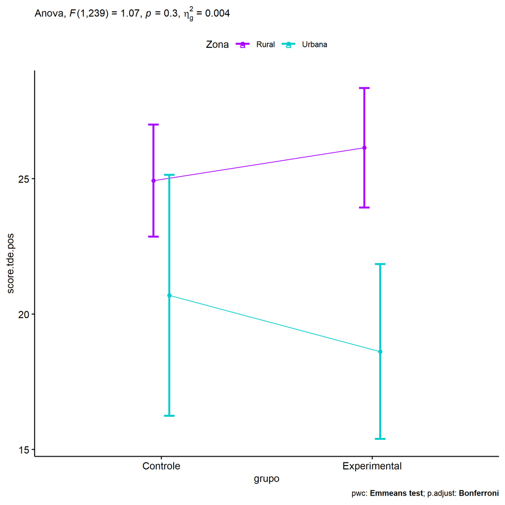

```r
if (!is.null(plots[["grupo"]]))
  plots[["grupo"]] + ggplot2::scale_color_manual(values = color[["Zona"]])
```

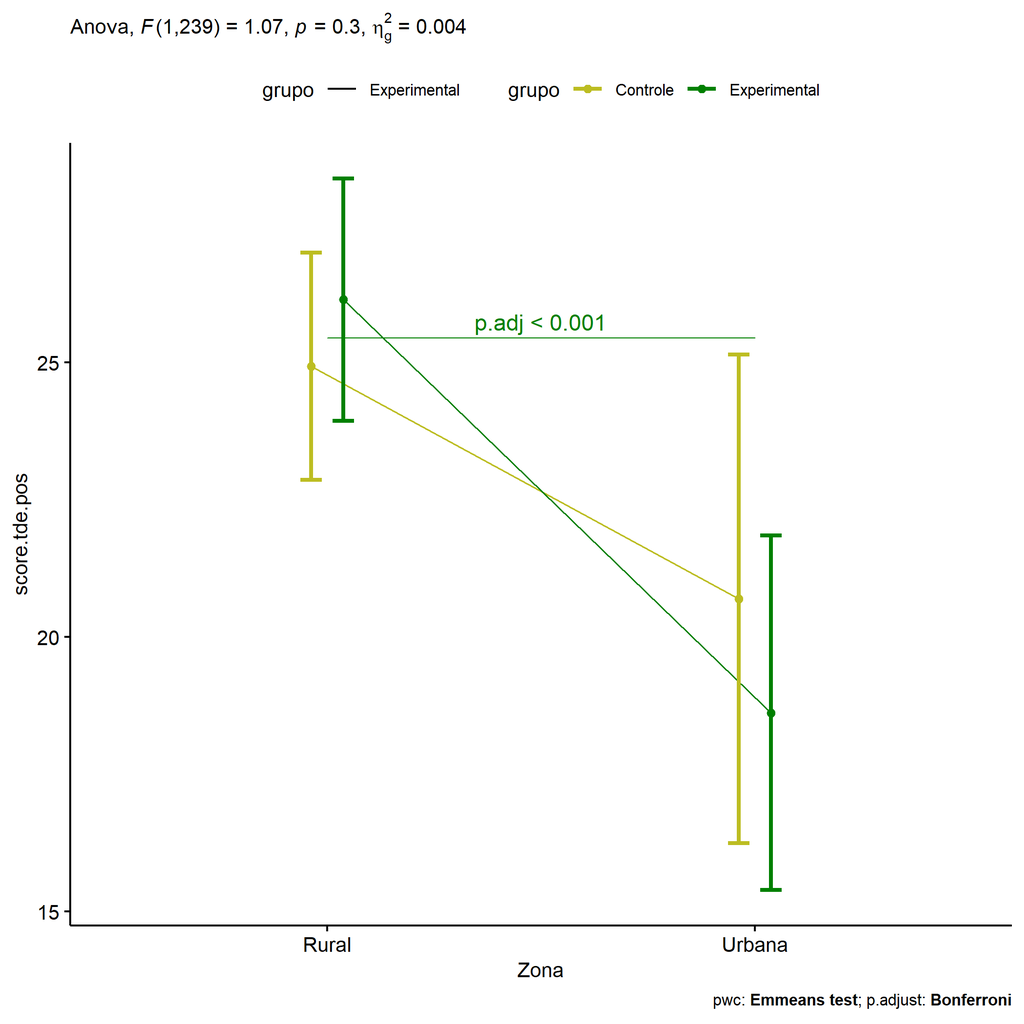

```r
if (!is.null(plots[["Zona"]]))
  plots[["Zona"]] + ggplot2::scale_color_manual(values = color[["grupo"]])
```

```r
plots <- twoWayAncovaBoxPlots(
  wdat, "score.tde.pos", c("grupo","Zona"), aov, pwcs, covar = "score.tde.pre",
  theme = "classic", color = color[["grupo:Zona"]],
  subtitle = which(aov$Effect == "grupo:Zona"))
```

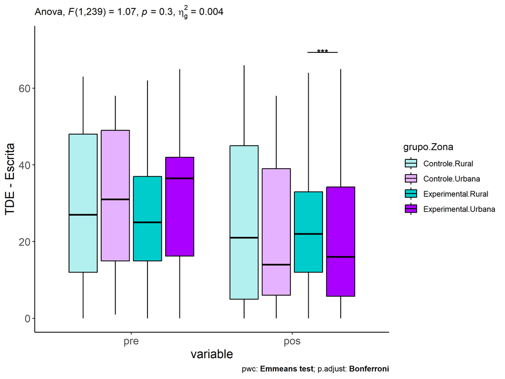

```r
plots[["grupo:Zona"]] + ggplot2::ylab("TDE - Escrita") + ggplot2::scale_x_discrete(labels=c('pre', 'pos'))
```

```r
plots <- twoWayAncovaBoxPlots(
  wdat.long, "score.tde", c("grupo","Zona"), aov, pwc.long, pre.post = "time",
  theme = "classic", color = color$prepost)
```

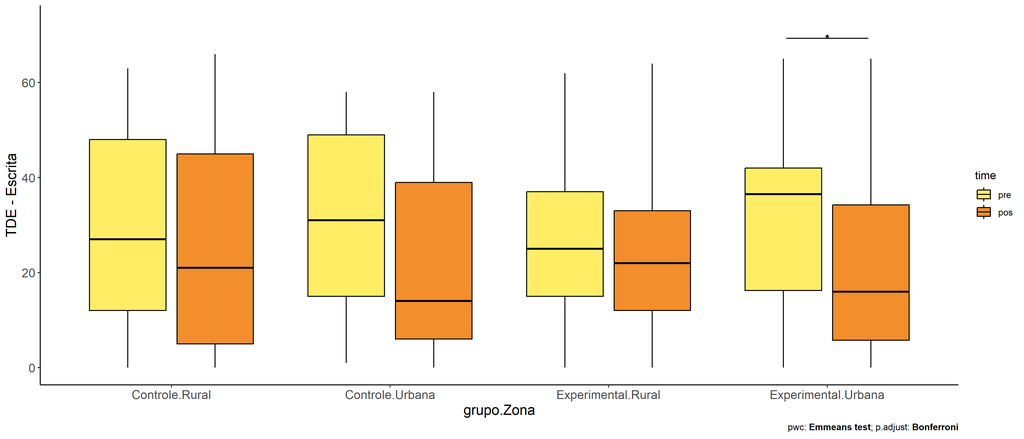

```r
plots[["grupo:Zona"]] + ggplot2::ylab("TDE - Escrita")
```

### Checking linearity assumption

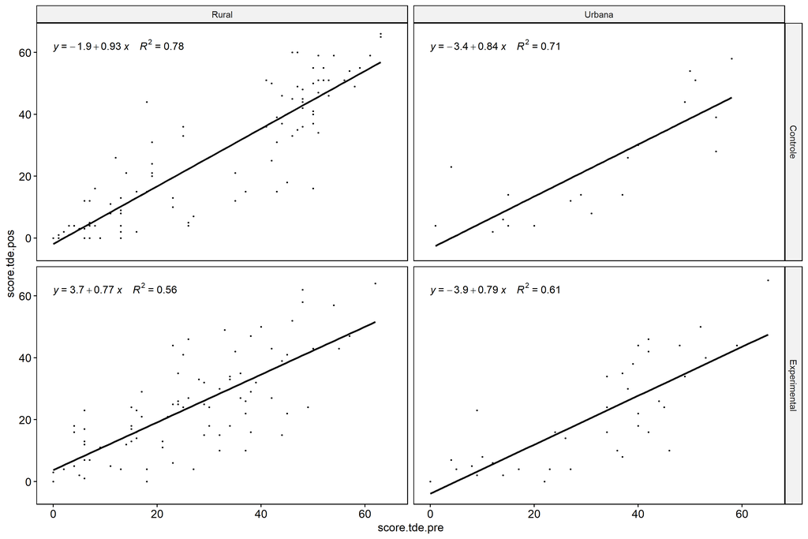

```r
ggscatter(wdat, x = "score.tde.pre", y = "score.tde.pos", size = 0.5,
          facet.by = c("grupo","Zona"), add = "reg.line")+
  stat_regline_equation(
    aes(label =  paste(..eq.label.., ..rr.label.., sep = "~~~~"))
  )
```

### Checking normality and homogeneity

```r
res <- augment(lm(score.tde.pos ~ score.tde.pre + grupo*Zona, data = wdat))
```

```r
shapiro_test(res$.resid)
```

```
## # A tibble: 1 × 3
##   variable   statistic p.value
##   <chr>          <dbl>   <dbl>
## 1 res$.resid     0.995   0.630
```

```r
levene_test(res, .resid ~ grupo*Zona)
```

```
## # A tibble: 1 × 4
##     df1   df2 statistic     p
##   <int> <int>     <dbl> <dbl>
## 1     3   240     0.462 0.709
```

# ANCOVA and Pairwise for two factors **grupo:Cor.Raca**

## Without remove non-normal data

```r
pdat = remove_group_data(dat[!is.na(dat[["grupo"]]) & !is.na(dat[["Cor.Raca"]]),], "score.tde.pos", c("grupo","Cor.Raca"))

pdat.long <- rbind(pdat[,c("id","grupo","Cor.Raca")], pdat[,c("id","grupo","Cor.Raca")])
pdat.long[["time"]] <- c(rep("pre", nrow(pdat)), rep("pos", nrow(pdat)))
pdat.long[["time"]] <- factor(pdat.long[["time"]], c("pre","pos"))
pdat.long[["score.tde"]] <- c(pdat[["score.tde.pre"]], pdat[["score.tde.pos"]])

aov = anova_test(pdat, score.tde.pos ~ score.tde.pre + grupo*Cor.Raca)
laov[["grupo:Cor.Raca"]] <- get_anova_table(aov)
```

```r
pwcs <- list()
pwcs[["Cor.Raca"]] <- emmeans_test(
  group_by(pdat, grupo), score.tde.pos ~ Cor.Raca,
  covariate = score.tde.pre, p.adjust.method = "bonferroni")
pwcs[["grupo"]] <- emmeans_test(
  group_by(pdat, Cor.Raca), score.tde.pos ~ grupo,
  covariate = score.tde.pre, p.adjust.method = "bonferroni")

pwc <- plyr::rbind.fill(pwcs[["grupo"]], pwcs[["Cor.Raca"]])
pwc <- pwc[,c("grupo","Cor.Raca", colnames(pwc)[!colnames(pwc) %in% c("grupo","Cor.Raca")])]
```

```r
pwc.long <- emmeans_test(dplyr::group_by_at(pdat.long, c("grupo","Cor.Raca")),
                         score.tde ~ time,
                         p.adjust.method = "bonferroni")
lpwc[["grupo:Cor.Raca"]] <- plyr::rbind.fill(pwc, pwc.long)
```

```r
ds <- get.descriptives(pdat, "score.tde.pos", c("grupo","Cor.Raca"), covar = "score.tde.pre")
ds <- merge(ds[ds$variable != "score.tde.pre",],
            ds[ds$variable == "score.tde.pre", !colnames(ds) %in% c("variable")],
            by = c("grupo","Cor.Raca"), all.x = T, suffixes = c("", ".score.tde.pre"))
ds <- merge(get_emmeans(pwcs[["grupo"]]), ds, by = c("grupo","Cor.Raca"), suffixes = c(".emms", ""))
ds <- ds[,c("grupo","Cor.Raca","n","mean.score.tde.pre","se.score.tde.pre","mean","se","emmean","se.emms")]

colnames(ds) <- c("grupo","Cor.Raca", "N", paste0(c("M","SE")," (pre)"),
                  paste0(c("M","SE"), " (unadj)"), paste0(c("M", "SE"), " (adj)"))

lemms[["grupo:Cor.Raca"]] <- ds
```

## Computing ANCOVA and PairWise After removing non-normal data (OK)

```r
wdat = pdat

res = residuals(lm(score.tde.pos ~ score.tde.pre + grupo*Cor.Raca, data = wdat))
non.normal = getNonNormal(res, wdat$id, plimit = 0.05)

wdat = wdat[!wdat$id %in% non.normal,]

wdat.long <- rbind(wdat[,c("id","grupo","Cor.Raca")], wdat[,c("id","grupo","Cor.Raca")])
wdat.long[["time"]] <- c(rep("pre", nrow(wdat)), rep("pos", nrow(wdat)))
wdat.long[["time"]] <- factor(wdat.long[["time"]], c("pre","pos"))
wdat.long[["score.tde"]] <- c(wdat[["score.tde.pre"]], wdat[["score.tde.pos"]])


ldat[["grupo:Cor.Raca"]] = wdat

(non.normal)
```

```r
aov = anova_test(wdat, score.tde.pos ~ score.tde.pre + grupo*Cor.Raca)
laov[["grupo:Cor.Raca"]] <- merge(get_anova_table(aov), laov[["grupo:Cor.Raca"]], by="Effect", suffixes = c("","'"))

(df = get_anova_table(aov))
```

```
## ANOVA Table (type II tests)
##
##           Effect DFn DFd       F        p p<.05      ges
## 1  score.tde.pre   1 128 239.421 4.26e-31     * 0.652000
## 2          grupo   1 128   0.887 3.48e-01       0.007000
## 3       Cor.Raca   2 128   2.477 8.80e-02       0.037000
## 4 grupo:Cor.Raca   1 128   0.080 7.78e-01       0.000625
```

| Effect | DFn | DFd | F | p | p<.05 | ges |
| --- | --- | --- | --- | --- | --- | --- |
| score.tde.pre | 1 | 128 | 239.421 | 0.000 | * | 0.652 |
| grupo | 1 | 128 | 0.887 | 0.348 |  | 0.007 |
| Cor.Raca | 2 | 128 | 2.477 | 0.088 |  | 0.037 |
| grupo:Cor.Raca | 1 | 128 | 0.080 | 0.778 |  | 0.001 |

```r
pwcs <- list()
pwcs[["Cor.Raca"]] <- emmeans_test(
  group_by(wdat, grupo), score.tde.pos ~ Cor.Raca,
  covariate = score.tde.pre, p.adjust.method = "bonferroni")
pwcs[["grupo"]] <- emmeans_test(
  group_by(wdat, Cor.Raca), score.tde.pos ~ grupo,
  covariate = score.tde.pre, p.adjust.method = "bonferroni")

pwc <- plyr::rbind.fill(pwcs[["grupo"]], pwcs[["Cor.Raca"]])
pwc <- pwc[,c("grupo","Cor.Raca", colnames(pwc)[!colnames(pwc) %in% c("grupo","Cor.Raca")])]
```

| grupo | Cor.Raca | term | .y. | group1 | group2 | df | statistic | p | p.adj | p.adj.signif |
| --- | --- | --- | --- | --- | --- | --- | --- | --- | --- | --- |
|  | Branca | score.tde.pre*grupo | score.tde.pos | Controle | Experimental | 128 | -0.758 | 0.450 | 0.450 | ns |
|  | Indígena | score.tde.pre*grupo | score.tde.pos | Controle | Experimental |  |  |  |  |  |
|  | Parda | score.tde.pre*grupo | score.tde.pos | Controle | Experimental | 128 | -0.630 | 0.530 | 0.530 | ns |
| Controle |  | score.tde.pre*Cor.Raca | score.tde.pos | Branca | Indígena |  |  |  |  |  |
| Controle |  | score.tde.pre*Cor.Raca | score.tde.pos | Branca | Parda | 128 | 0.149 | 0.882 | 0.882 | ns |
| Controle |  | score.tde.pre*Cor.Raca | score.tde.pos | Indígena | Parda |  |  |  |  |  |
| Experimental |  | score.tde.pre*Cor.Raca | score.tde.pos | Branca | Indígena | 128 | -1.624 | 0.107 | 0.320 | ns |
| Experimental |  | score.tde.pre*Cor.Raca | score.tde.pos | Branca | Parda | 128 | 0.594 | 0.554 | 1.000 | ns |
| Experimental |  | score.tde.pre*Cor.Raca | score.tde.pos | Indígena | Parda | 128 | 2.237 | 0.027 | 0.081 | ns |

```r
pwc.long <- emmeans_test(dplyr::group_by_at(wdat.long, c("grupo","Cor.Raca")),
                         score.tde ~ time,
                         p.adjust.method = "bonferroni")
lpwc[["grupo:Cor.Raca"]] <- merge(plyr::rbind.fill(pwc, pwc.long), lpwc[["grupo:Cor.Raca"]], by=c("grupo","Cor.Raca","term",".y.","group1","group2"), suffixes = c("","'"))
```

| grupo | Cor.Raca | term | .y. | group1 | group2 | df | statistic | p | p.adj | p.adj.signif |
| --- | --- | --- | --- | --- | --- | --- | --- | --- | --- | --- |
| Controle | Branca | time | score.tde | pre | pos | 258 | 1.202 | 0.231 | 0.231 | ns |
| Controle | Indígena | time | score.tde | pre | pos |  |  |  |  |  |
| Controle | Parda | time | score.tde | pre | pos | 258 | 1.676 | 0.095 | 0.095 | ns |
| Experimental | Branca | time | score.tde | pre | pos | 258 | 0.490 | 0.624 | 0.624 | ns |
| Experimental | Indígena | time | score.tde | pre | pos | 258 | -0.514 | 0.608 | 0.608 | ns |
| Experimental | Parda | time | score.tde | pre | pos | 258 | 1.359 | 0.175 | 0.175 | ns |

```r
ds <- get.descriptives(wdat, "score.tde.pos", c("grupo","Cor.Raca"), covar = "score.tde.pre")
ds <- merge(ds[ds$variable != "score.tde.pre",],
            ds[ds$variable == "score.tde.pre", !colnames(ds) %in% c("variable")],
            by = c("grupo","Cor.Raca"), all.x = T, suffixes = c("", ".score.tde.pre"))
ds <- merge(get_emmeans(pwcs[["grupo"]]), ds, by = c("grupo","Cor.Raca"), suffixes = c(".emms", ""))
ds <- ds[,c("grupo","Cor.Raca","n","mean.score.tde.pre","se.score.tde.pre","mean","se","emmean","se.emms")]

colnames(ds) <- c("grupo","Cor.Raca", "N", paste0(c("M","SE")," (pre)"),
                  paste0(c("M","SE"), " (unadj)"), paste0(c("M", "SE"), " (adj)"))

lemms[["grupo:Cor.Raca"]] <- merge(ds, lemms[["grupo:Cor.Raca"]], by=c("grupo","Cor.Raca"), suffixes = c("","'"))
```

| grupo | Cor.Raca | N | M (pre) | SE (pre) | M (unadj) | SE (unadj) | M (adj) | SE (adj) |
| --- | --- | --- | --- | --- | --- | --- | --- | --- |
| Controle | Branca | 17 | 35.000 | 5.000 | 27.647 | 5.369 | 21.215 | 2.647 |
| Controle | Parda | 39 | 28.410 | 3.086 | 21.641 | 3.238 | 20.745 | 1.727 |
| Experimental | Branca | 22 | 22.318 | 3.285 | 19.682 | 3.186 | 23.903 | 2.314 |
| Experimental | Indígena | 11 | 21.818 | 4.865 | 25.727 | 4.995 | 30.369 | 3.264 |
| Experimental | Parda | 45 | 27.333 | 2.347 | 22.222 | 2.449 | 22.231 | 1.607 |